# Project 3: Data Science Skills

### Importing Scraped Data to MySQL from R (ETL)

#### Bruce Hao, Aaron Grzasko

##### Summary:

Although the data acquisition, exploration and analysis processes were conducted in R, the data is stored in MySQL to faciliate permanent storage and access. This step is comprised of several sub-steps outlined below:

- Read data from data acquisition process into data frame (note: in the code below, the data was read in from a csv file, but could just as easily be read in directly from the web scraping output).
- Transform data to ready it for import into the correct database tables. In this particular case, there are three tables to house unique roles, locations and keywords, and there are two tables that facilitate the many-to-many relationships.
- Create connection to MySQL database and import data into respective tables.

##### Future Work:

- Add flexibility to import scripts. As is, the scripts below assign primary keys based as 1:n and are thus designed for a one-time import of data. Subsequent incremental imports will fail due to duplicate primary keys. This can be resolved by having the database auto-increment additions and remove duplicates.
- Currently, the transform and load process requires 3-4 lines of code for each table. A function could be used to minimize replicating similar code for each database table. The function would need to be flexible enough to deal with different column numbers and names within each table.

##### Summary of Code:

```r
library(stringr)
library(dplyr)
library(dbConnect)


#Create connection to database and load acquired data into data frame.

username = 'data607'
password = 'project3'
dbname = 'ds_skills'
host = 'data607-project3.ce2dfe0qxt5q.us-west-2.rds.amazonaws.com'
myDb = dbConnect(MySQL(), user=username, password=password, dbname=dbname, host=host)

my_data <- read.csv("data.csv", stringsAsFactors = FALSE)


# * Remove duplicates and non-SQL-friendly characters from data to be imported
# * Create primary key (ID) for each unique record to be imported
# * Create string to house values to be inserted in SQL query
# * Run INSERT query to import data into SQL
# * Repeat process for each of the five database tables


#roles df
role_desc <- unique(str_replace(my_data$Job_Title, "\\'", ""))  # BH: removed apostrophes for SQL

#import
role_id <- seq.int(length(role_desc))
roles <- data.frame(role_id=role_id,role_desc=role_desc)
roles = roles %>% mutate(insertValue = paste0("(", role_id, ", '", role_desc, "')"))
insertValues = paste(unlist(roles$insertValue), collapse = ', ')
insertQry = dbSendQuery(myDb, paste0("INSERT INTO roles VALUES ", insertValues, ";"))
fetch(insertQry, n = -1)

#location df
locations <- unique(my_data[,c("City","State")])
locations <- cbind(loc_id =  seq.int(nrow(locations)), locations)
locations = locations %>% mutate(insertValue = paste0("(", loc_id, ", '", City, "', '", State, "')"))
insertValues = paste(unlist(locations$insertValue), collapse = ', ')
insertQry = dbSendQuery(myDb, paste0("INSERT INTO locations VALUES ", insertValues, ";"))
fetch(insertQry, n = -1)

#keywords df
key_list <- unlist(str_split(tolower(my_data$keywordtag),","))
key_desc <- unique(key_list[key_list!=""])
key_id <- seq.int(length(key_desc))
keywords <- data.frame(key_id = key_id, key_desc = key_desc)
keywords = keywords %>% mutate(insertValue = paste0("(", key_id, ", '", key_desc, "')"))
insertValues = paste(unlist(keywords$insertValue), collapse = ', ')
insertQry = dbSendQuery(myDb, paste0("INSERT INTO keywords VALUES ", insertValues, ";"))
fetch(insertQry, n = -1)

#post_keys df
key_list <- str_split(tolower(my_data$keywordtag),",")
key_list <- lapply(key_list,unique)
post_id = integer(); key_desc = character()
for (i in 1:length(key_list)){
  for (j in 1:length(key_list[[i]])) {
    post_id <- append(post_id,i)
    key_desc <- append(key_desc,key_list[[i]][[j]])
  }
}
post_keys <- data.frame(post_id = post_id,key_desc = key_desc)
post_keys <- filter(post_keys, key_desc != "" & key_desc !=" ")
post_keys <- merge(keywords, post_keys, by = "key_desc")
post_keys <- subset(post_keys, select = c(post_id, key_id))
post_keys = post_keys %>% mutate(insertValue = paste0("(", post_id, ", '", key_id, "')"))
insertValues = paste(unlist(post_keys$insertValue), collapse = ', ')
insertQry = dbSendQuery(myDb, paste0("INSERT INTO post_keys VALUES ", insertValues, ";"))
fetch(insertQry, n = -1)

#jobs df
jobs <- my_data
names(jobs)[names(jobs)=="Job_Title"] <- "role_desc"
jobs$post_id <-seq.int(nrow(jobs))
jobs <- merge(jobs, roles, by ="role_desc")
jobs <- merge(jobs, locations, by= c("City","State"))
jobs <- subset(jobs, select= c(post_id,role_id,loc_id))
jobs = jobs %>% mutate(insertValue = paste0("(", post_id, ", ", role_id, ", ", loc_id, ")"))
insertValues = paste(unlist(jobs$insertValue), collapse = ', ')
insertQry = dbSendQuery(myDb, paste0("INSERT INTO jobs VALUES ", insertValues, ";"))
fetch(insertQry, n = -1)
```

### Analysis

#### Andrew Carson

##### Load Data

Now we load the data from the MySQL database. First, a connection is created, then a query is formed. The query is fetched and the results are returned.

```r
# Clear Workspace
rm(list=ls())

library(dbConnect)


#set variables for connecting to MySQL
username = 'data607'

password = 'project3'

dbname = 'ds_skills'

host = 'data607-project3.ce2dfe0qxt5q.us-west-2.rds.amazonaws.com'

myDb = dbConnect(MySQL(), user=username, password=password, dbname=dbname, host=host)


#write query string to pull data from tables in MySQL
qryString = 'SELECT jobs.post_id, role_desc, city, state, keyword_desc

FROM jobs

INNER JOIN locations

ON jobs.loc_id = locations.loc_id

INNER JOIN roles

ON jobs.role_id = roles.role_id

INNER JOIN post_keys

ON jobs.post_id = post_keys.post_id

INNER JOIN  keywords

ON post_keys.key_id = keywords.key_id

;'


#pull query
selectQry = dbSendQuery(myDb, qryString)
results = fetch(selectQry, n = -1)

#display first 10 rows
head(results, n=10)
```

```
##    post_id                      role_desc         city state keyword_desc
## 1      240               sr-data-engineer      seattle    wa          bi
## 2      286 etl-specialist-big-data-develo eden-prairie    mn          bi
## 3      426              sr-data-scientist     bellevue    wa          bi
## 4      417 senior-analytics-software-engi         azle    tx          bi
## 5      128 senior-analytics-software-engi         azle    tx          bi
## 6      176                  data-engineer      seattle    wa          bi
## 7      227 senior-data-engineer-digital-m      seattle    wa          bi
## 8      180 data-visualization-engineer-ch      malvern    pa          bi
## 9       82              sr-data-scientist      seattle    wa          bi
## 10     261 big-data-cloud-solution-archit      atlanta    ga          bi
```

##### Analysis

Our task is to answer the question: “Which are the most valued data science skills?” The easiest way to answer this is to look at the most frequent keywords in our dataset.

```r
library(ggplot2)
library(tidyr)
library(dplyr)
library(knitr)
library(DT)
library(stringr)

#trim white space
results$keyword_desc<-str_trim(results$keyword_desc)

# counts of keywords
keyword_counts<-data.frame(table(results$keyword_desc))
names(keyword_counts)<-c("Keyword","Freq")
keyword_counts$Keyword<-as.character(keyword_counts$Keyword)
head(arrange(keyword_counts,desc(Freq)), n=11)
```

```
##             Keyword Freq
## 1     communication  199
## 2             excel  177
## 3              java  136
## 4               sql  136
## 5  machine learning  126
## 6            python  123
## 7          big data  118
## 8              math  118
## 9            hadoop  106
## 10       statistics  105
## 11                r   87
```

We see that communication tops the list, followed by Excel, JAVA, SQL, machine learning, and Python. R comes in at number 11.

We add a plot to visualize the result.

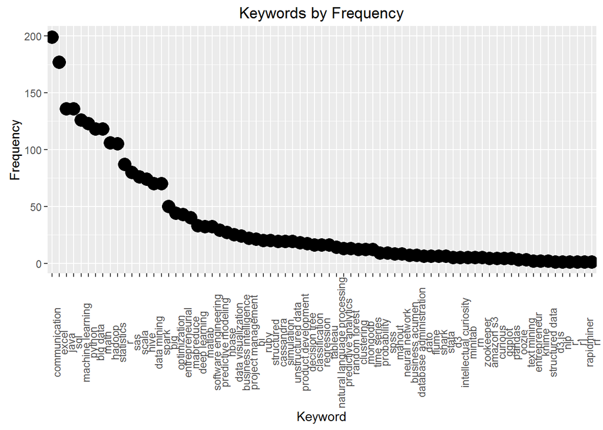

```r
#plot of keyword counts
qplot(data = keyword_counts, x = reorder(Keyword, -Freq), y=Freq, xlab="Keyword", ylab="Frequency", main = "Keywords by Frequency", size=I(5)) +
      theme(text = element_text(),
        axis.text.x = element_text(angle=90, vjust=1))
```

Overall, we see programming languages (JAVA, Python), statistical languages (R, SAS), big data languages(Pig, Hive), big data technologies (mapreduce, Hadoop), standard data skills (Excel, SQL), and visualization (Tableau, d3). We also see a lot of “soft skills” or broad topic knowledge like communication, deep learning, math, “big data”, “data mining”, etc.

Adding nuance, what sorts of roles are we looking at that matched our search query when finding data?

```r
#count of role description
distinct_roles<-distinct(select(results, post_id,role_desc))
distinct_roles<-data.frame(table(distinct_roles$role_desc))
names(distinct_roles)<-c("Role","Freq")
head(arrange(distinct_roles,desc(Freq)), n=10)
```

```
##                              Role Freq
## 1                  data-scientist   30
## 2                              NA   14
## 3  data-scientist-amazon-advertis    7
## 4      machine-learning-scientist    7
## 5  senior-analytics-software-engi    6
## 6     aflac-insurance-sales-agent    5
## 7                   data-engineer    5
## 8  software-development-engineer-    5
## 9               sr-data-scientist    5
## 10 sr-programmer-sr-statistician-    5
```

[figure not shown]

```r
#plot of role description
qplot(data = subset(distinct_roles, Freq>3), x = reorder(Role, -Freq), y=Freq, xlab="Role", ylab="Frequency", main = "Role by Frequency", size=I(5)) +
      theme(text = element_text(),
        axis.text.x = element_text(angle=90, vjust=1))
```

The most frequent is “data-scientist”, which makes sense since this is what we were looking for. We can also see “machine-learning”, “software-engineer”, and “statistician” in the list. Most role descriptions are unique, but could be further grouped if desired.

How do roles and skills align? Take a look at the below table, and sort on the keyword to find which job titles use this skill the most:

```r
#role vs. keyword counts
role_vs_Keyword<-results %>%
  select(role_desc,keyword_desc) %>%
  group_by(role_desc, keyword_desc) %>%
  count(role_desc, keyword_desc) %>%
  spread(role_desc,n)


#keyword vs. role
keyword_vs_role<-results %>%
  select(role_desc,keyword_desc) %>%
  group_by(role_desc, keyword_desc) %>%
  count(role_desc, keyword_desc) %>%
  spread(keyword_desc,n)

#which roles require which skills?
datatable(keyword_vs_role)
```

|  | role_desc | amazon s3 | bi | big data | business acumen | business intelligence | cassandra | classification | clustering | communication | curious | d3 | d3.js | data mining | data visualization | database administration | dato | decision tree | deep learning | entrepreneur | entrepreneurial | excel | flume | ggplot | hadoop | hbase | hive | intellectual curiosity | java | … |
| --- | --- | --- | --- | --- | --- | --- | --- | --- | --- | --- | --- | --- | --- | --- | --- | --- | --- | --- | --- | --- | --- | --- | --- | --- | --- | --- | --- | --- | --- | --- |
| 1 | advanced-analytics-data-scient |  |  |  |  |  |  |  |  | 2 | 2 |  |  | 2 |  |  |  |  |  |  |  | 2 |  |  |  |  |  |  | 2 | … |
| 2 | advanced-data-analytics-scient |  |  | 1 | 1 |  |  |  |  |  |  |  |  | 1 |  |  |  |  |  |  |  | 1 |  |  | 1 |  | 1 |  |  | … |
| 3 | aflac-insurance-sales-agent |  |  |  |  |  |  |  |  |  |  |  |  |  |  |  |  |  |  |  | 5 |  |  |  |  |  |  |  |  | … |
| 4 | analytical-chemist |  |  |  |  |  |  |  |  |  |  |  |  |  |  |  |  |  |  |  |  | 3 |  |  |  |  |  |  |  | … |
| 5 | applied-mathematician-physicis |  |  |  |  |  |  |  |  |  |  |  |  |  |  |  |  |  |  |  |  |  |  |  |  |  |  |  |  | … |
| 6 | applied-scientist |  |  |  |  |  |  |  |  |  |  |  |  |  |  |  |  |  | 1 |  |  |  |  |  |  |  |  |  | 1 | … |
| 7 | applied-scientist-machine-lear |  |  |  |  |  |  |  |  | 1 |  |  |  |  |  |  |  |  | 2 |  |  | 1 |  |  |  |  |  |  | 2 | … |
| 8 | apps-systems-engineer-4-ab-ini |  |  |  |  |  |  |  |  |  |  |  |  |  |  |  |  |  |  |  |  |  |  |  |  |  |  |  | 1 | … |
| 9 | associate-data-scientist-san-a |  |  |  |  |  |  |  |  |  |  |  |  |  |  |  |  |  |  |  |  | 2 |  |  |  |  |  |  |  | … |
| 10 | associate-director-statistical |  |  |  |  |  |  |  |  | 1 |  |  |  |  |  |  |  |  |  |  |  | 1 |  |  |  |  |  |  | 1 | … |

[output cut: 178 more lines]

Since we are most interested in “data scientists”, let’s look at job titles that match “data-scientist”:

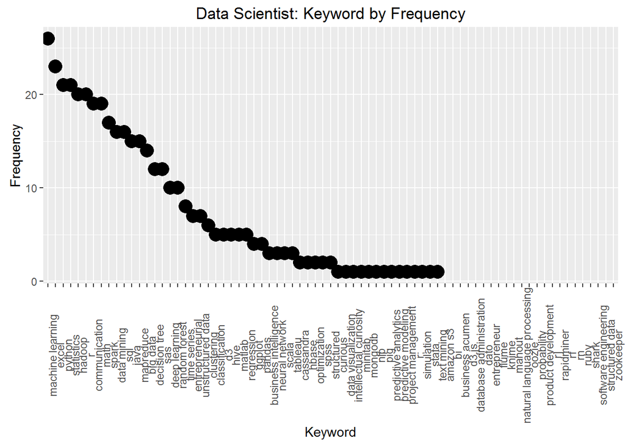

```r
# show top keywords for data-scientist
top_data_scientist<-
  arrange(role_vs_Keyword, desc(`data-scientist`)) %>%
  select(keyword_desc, `data-scientist`)

#plot data-scientist
qplot(data = top_data_scientist, x = reorder(keyword_desc, -`data-scientist`), y=`data-scientist`, xlab="Keyword", ylab="Frequency", main = "Data Scientist: Keyword by Frequency", size=I(5)) +
      theme(text = element_text(),
        axis.text.x = element_text(angle=90, vjust=1))
```

Machine learning, Excel, Python, statistics, Hadoop, R, and communication are the top skills.

What about anything that matches the pattern “data-scien”? This will include all levels of data scientists and other job titles that have this pattern in it.

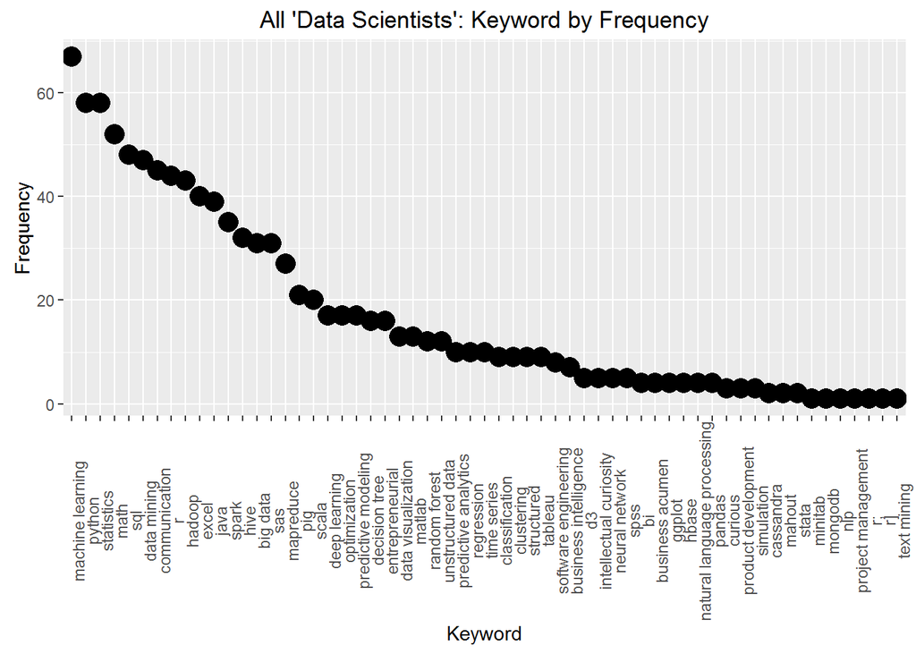

```r
# show top keywords for anything like data scientist
top_data_scientist_all<-
  results %>%
  subset(str_detect(role_desc,"data-scien")) %>%
  select(keyword_desc) %>%
  group_by(keyword_desc) %>%
  count(keyword_desc) %>%
  arrange(desc(n))

#plot data-scientist: all
qplot(data = top_data_scientist_all, x = reorder(keyword_desc, -n), y=n, xlab="Keyword", ylab="Frequency", main = "All 'Data Scientists': Keyword by Frequency", size=I(5)) +
      theme(text = element_text(),
        axis.text.x = element_text(angle=90, vjust=1))
```

We have machine learning, Python, Statistics, Math, SQL, data mining, communication, and R.

Where are these jobs being offered? We collected the city and state information with these job postings:

```r
#count of city
distinct_city<-distinct(select(results, post_id, city))
distinct_city<-data.frame(table(distinct_city$city))
names(distinct_city)<-c("city","Freq")
head(arrange(distinct_city,desc(Freq)), n=10)
```

```
##            city Freq
## 1       seattle   69
## 2            NA   14
## 3       chicago   10
## 4         plano    9
## 5        boston    7
## 6       redmond    7
## 7   santa-clara    7
## 8          azle    6
## 9      bellevue    6
## 10 philadelphia    6
```

Seattle is the top city at 69, followed by Chicago at 10, and Plano at 9.

What is your city’s favorite data science skill?

```r
#city vs. keyword counts
city_vs_Keyword<-results %>%
  select(city,keyword_desc) %>%
  group_by(city, keyword_desc) %>%
  count(city, keyword_desc) %>%
  spread(city,n)

#keyword vs. city counts
keyword_vs_city<-results %>%
  select(city,keyword_desc) %>%
  group_by(city, keyword_desc) %>%
  count(city, keyword_desc) %>%
  spread(keyword_desc,n)

datatable(keyword_vs_city)
```

|  | city | amazon s3 | bi | big data | business acumen | business intelligence | cassandra | classification | clustering | communication | curious | d3 | d3.js | data mining | data visualization | database administration | dato | decision tree | deep learning | entrepreneur | entrepreneurial | excel | flume | ggplot | hadoop | hbase | hive | intellectual curiosity | java | … |
| --- | --- | --- | --- | --- | --- | --- | --- | --- | --- | --- | --- | --- | --- | --- | --- | --- | --- | --- | --- | --- | --- | --- | --- | --- | --- | --- | --- | --- | --- | --- |
| 1 | addison |  |  |  |  |  |  |  |  |  |  |  |  |  |  |  |  |  |  |  |  |  |  |  |  | 1 |  |  |  | … |
| 2 | aiken |  |  |  |  |  |  |  |  |  |  |  |  |  |  |  |  |  |  |  |  | 2 |  |  |  |  |  |  |  | … |
| 3 | alpharetta |  |  | 3 |  |  |  |  |  |  |  |  |  |  | 3 |  |  |  |  |  |  |  |  |  | 3 |  | 3 |  | 3 | … |
| 4 | arlington |  |  |  |  |  |  |  |  | 3 |  |  |  |  | 1 |  |  |  |  | 2 | 2 | 1 |  |  |  |  |  |  | 1 | … |
| 5 | atlanta |  | 1 | 4 |  |  | 1 |  |  | 4 |  |  |  | 3 |  |  |  | 2 |  |  | 2 | 3 |  |  | 5 | 1 | 2 |  | 2 | … |
| 6 | azle |  | 6 | 6 |  |  |  |  |  | 6 |  |  |  | 6 |  |  |  |  |  |  |  |  |  |  | 6 |  |  |  |  | … |
| 7 | basking-ridge |  |  | 2 | 1 |  |  |  |  | 1 |  |  | 1 | 2 |  |  |  |  |  |  |  | 1 |  |  | 2 |  | 2 |  | 1 | … |
| 8 | belleville |  |  |  |  |  |  |  |  |  |  |  |  |  |  |  |  |  |  |  |  |  |  |  |  |  |  |  |  | … |
| 9 | bellevue |  | 2 | 4 |  |  |  |  |  | 2 |  |  |  | 4 |  |  |  |  |  |  |  | 2 |  |  | 4 |  | 2 | 2 | 2 | … |
| 10 | bellingham |  |  |  |  |  |  |  |  | 3 |  |  |  |  |  |  |  |  |  |  |  |  |  |  |  |  |  |  |  | … |

[output cut: 114 more lines]

Finally, we have the state. Washington, California, and Texas have the most job postings. Which skills does your state prefer?

```r
#count of state
distinct_state<-distinct(select(results, post_id, state))
distinct_state<-data.frame(table(distinct_state$state))
names(distinct_state)<-c("state","Freq")
head(arrange(distinct_state,desc(Freq)), n=10)
```

```
##    state Freq
## 1     wa   97
## 2     ca   43
## 3     tx   25
## 4     il   24
## 5     nj   21
## 6     ma   18
## 7     NA   14
## 8     ny   13
## 9     va   12
## 10    ga   11
```

```r
#state vs. keyword counts
state_vs_Keyword<-results %>%
  select(state,keyword_desc) %>%
  group_by(state, keyword_desc) %>%
  count(state, keyword_desc) %>%
  spread(state,n)

#keyword vs. state counts
keyword_vs_state<-results %>%
  select(state,keyword_desc) %>%
  group_by(state, keyword_desc) %>%
  count(state, keyword_desc) %>%
  spread(keyword_desc,n)

datatable(keyword_vs_state)
```

|  | state | amazon s3 | bi | big data | business acumen | business intelligence | cassandra | classification | clustering | communication | curious | d3 | d3.js | data mining | data visualization | database administration | dato | decision tree | deep learning | entrepreneur | entrepreneurial | excel | flume | ggplot | hadoop | hbase | hive | intellectual curiosity | java | … |
| --- | --- | --- | --- | --- | --- | --- | --- | --- | --- | --- | --- | --- | --- | --- | --- | --- | --- | --- | --- | --- | --- | --- | --- | --- | --- | --- | --- | --- | --- | --- |
| 1 | al |  |  |  |  |  |  |  |  | 1 |  |  |  |  |  |  |  |  |  |  |  | 1 |  |  |  |  |  |  |  | … |
| 2 | az |  |  | 2 |  |  |  |  | 2 |  |  |  |  |  |  |  |  | 2 | 2 |  |  |  |  |  | 2 |  | 2 |  |  | … |
| 3 | ca |  |  | 17 | 4 | 1 | 4 | 3 |  | 23 |  |  |  | 9 | 4 |  | 1 |  | 6 |  | 4 | 22 | 4 |  | 16 | 8 | 15 |  | 21 | … |
| 4 | co |  |  | 1 |  |  |  |  |  | 1 |  |  |  | 1 |  |  |  |  |  |  |  | 1 | 1 |  | 1 |  |  |  | 1 | … |
| 5 | ct |  |  |  |  |  |  |  |  | 1 |  |  |  |  |  |  |  |  |  |  |  |  |  |  |  |  |  |  |  | … |
| 6 | dc |  |  |  |  |  |  |  |  |  |  |  |  |  |  |  |  |  |  |  |  | 4 |  |  |  |  |  |  |  | … |
| 7 | fl |  |  | 1 |  |  |  |  |  | 5 |  |  |  |  |  |  |  |  |  |  |  | 7 |  |  | 1 | 1 | 1 |  | 1 | … |
| 8 | ga |  | 1 | 9 |  | 1 | 1 |  |  | 6 |  |  |  | 3 | 3 |  |  | 2 |  |  | 2 | 6 |  |  | 10 | 2 | 6 |  | 7 | … |
| 9 | ia |  |  |  |  |  |  |  |  | 4 |  |  |  |  |  |  |  |  |  |  |  | 4 |  |  |  |  |  |  |  | … |
| 10 | id |  |  |  |  |  |  |  |  | 4 |  |  |  |  |  |  |  |  |  |  |  | 4 |  |  |  |  |  |  |  | … |

[output cut: 24 more lines]

```r
# Clear Workspace
rm(list=ls())
```

##### Conclusion

Our team found that many skills we expected to be popular were: Python, Excel, big data technologies, machine learning, SQL. Perhaps most surprising is that “communication” is the top skill. Clearly, “soft skills” are still very important even for more technically oriented data scientists.

Another surprising result was that R is not as popular as we thought it would be. This may be due to the difficulty of extracting “R” from the text of a job description, as we would expect it to be on par with Python in popularity. We did some work on getting better extraction of “R”, and while its numbers did improve, it still lags behind Python by quite a bit.

### Analytic Models

#### Daniel Thonn

##### Notes:

reference-1: “http//www.cs.ukzn.ac.za/~hughm/dm/content/slides06.pdf”

reference-2: “http//www.rdatamining.com/examples/decision-tree”

##### Setting up and Preparing the Environment

```r
#packages and libraries

#library for building basic decision tree
library(rpart)

#library for ctree decision tree
#install.packages("party")
library(party)

#library for randomForest decision tree
#install.packages("randomForest")
library(randomForest)

#install.packages("dbConnect")
library(dbConnect)

#install.packages("gplot2")
library(ggplot2)

#install.packages("tidyr")
library(tidyr)
library(dplyr)
library(knitr)
library(plyr)

#install.packages("caret")
library(caret)
```

##### Retreive data from database

```r
username = 'data607'
password = 'project3'
dbname = 'ds_skills'
host = 'data607-project3.ce2dfe0qxt5q.us-west-2.rds.amazonaws.com'
myDb = dbConnect(MySQL(), user=username, password=password, dbname=dbname, host=host)


qryString = 'SELECT jobs.post_id, role_desc, city, state, keyword_desc
             FROM jobs
             INNER JOIN locations
             ON jobs.loc_id = locations.loc_id
             INNER JOIN roles
             ON jobs.role_id = roles.role_id
             INNER JOIN post_keys
             ON jobs.post_id = post_keys.post_id
             INNER JOIN  keywords
             ON post_keys.key_id = keywords.key_id
             ;'


selectQry = dbSendQuery(myDb, qryString)
results = fetch(selectQry, n = -1)

#results
head(results)
```

```
##   post_id                      role_desc         city state keyword_desc
## 1     240               sr-data-engineer      seattle    wa          bi
## 2     286 etl-specialist-big-data-develo eden-prairie    mn          bi
## 3     426              sr-data-scientist     bellevue    wa          bi
## 4     417 senior-analytics-software-engi         azle    tx          bi
## 5     128 senior-analytics-software-engi         azle    tx          bi
## 6     176                  data-engineer      seattle    wa          bi
```

```r
#results
str(results)
```

```
## 'data.frame':    2610 obs. of  5 variables:
##  $ post_id     : int  240 286 426 417 128 176 227 180 82 261 ...
##  $ role_desc   : chr  "sr-data-engineer" "etl-specialist-big-data-develo" "sr-data-scientist" "senior-analytics-software-engi" ...
##  $ city        : chr  "seattle" "eden-prairie" "bellevue" "azle" ...
##  $ state       : chr  "wa" "mn" "wa" "tx" ...
##  $ keyword_desc: chr  " bi " " bi " " bi " " bi " ...
```

##### Create a graph of Role vs Sum of Skills for the top 10 roles

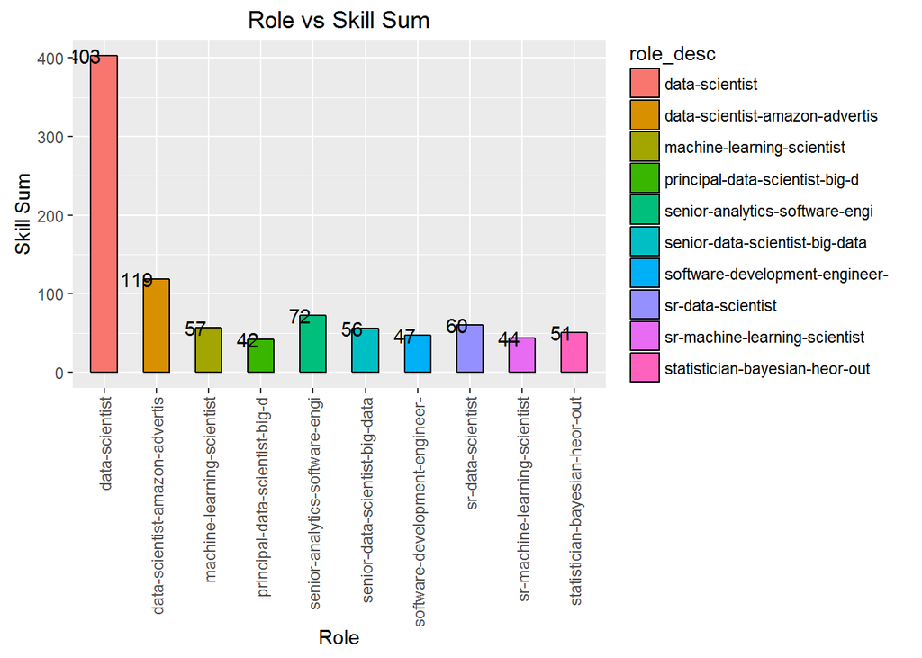

```r
results1 <- select(results, role_desc, keyword_desc)

results2 <- count(results1, c("role_desc", "keyword_desc"))

results3 <- spread(results2, keyword_desc, freq)

results3[is.na(results3)] <- 0
#results3

names(results3) <- sub(" ", "", names(results3))
names(results3) <- sub(" ", "", names(results3))
#results3

results4 <- results3
#results4
#head(results4)

# Add a row sum
results5 <- transform(results4, sum=rowSums(results4[,-1]))
#head(results5)

# Obtain two columns role_desc and sum
results6 <-  results5[ , c("role_desc","sum")]
#head(results6)

# Take top 10 roles order by skills descending
results7 <- head(arrange(results6,desc(sum)), n = 10)
#head(results7)
#str(results7)

# Graph Role vs Sum of Skills
results7 %>%
      ggplot( aes(x=role_desc, y=sum, fill=role_desc)) +
    geom_bar(stat="identity", position=position_dodge(), colour="black", width = 0.5) +
    ggtitle("Role vs Skill Sum") +
    xlab("Role") + ylab("Skill Sum") +
    geom_text(aes(label=paste(sum)), vjust=0.5, hjust=1.1,color="black") +
    theme(axis.text.x=element_text(angle=90,hjust=1,vjust=0.5))
```

##### Cleanup Data, plot Decistion Trees, and create Predictive Models

```r
#This section creates a table of non-distinct role_desc vs keyword_desc

#str(results)

role_vs_Keyword_a <- results %>%
  select(role_desc,keyword_desc)

head(role_vs_Keyword_a)
```

```
##                        role_desc keyword_desc
## 1               sr-data-engineer          bi
## 2 etl-specialist-big-data-develo          bi
## 3              sr-data-scientist          bi
## 4 senior-analytics-software-engi          bi
## 5 senior-analytics-software-engi          bi
## 6                  data-engineer          bi
```

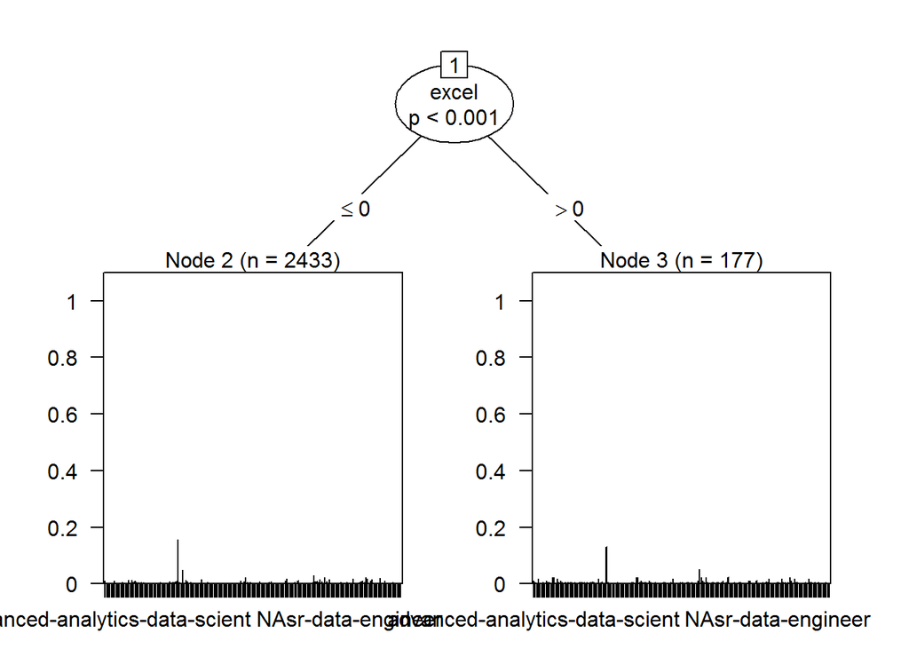

```r
#str(role_vs_Keyword_a)

role_vs_Keyword_b <- role_vs_Keyword_a
#head(role_vs_Keyword_b)
role_vs_Keyword_b2 <- role_vs_Keyword_b
#head(role_vs_Keyword_b2)
#str(role_vs_Keyword_b2)
#role_vs_Keyword_b2$keyword_desc
role_vs_Keyword_b2$keyword_desc <- gsub(" r;", "r",role_vs_Keyword_b2$keyword_desc)
role_vs_Keyword_b2$keyword_desc <- gsub("r ", "r",role_vs_Keyword_b2$keyword_desc)
role_vs_Keyword_b2$keyword_desc <- gsub(" r", "r",role_vs_Keyword_b2$keyword_desc)
role_vs_Keyword_b2$keyword_desc <- gsub("r] ", "r",role_vs_Keyword_b2$keyword_desc)
role_vs_Keyword_b2$row <- rep(1,nrow(role_vs_Keyword_b2))
role_vs_Keyword_b2$row2 <- 1:nrow(role_vs_Keyword_b2)
#head(role_vs_Keyword_b2)

# Spread keyword values to columns
wide <- spread(role_vs_Keyword_b2,keyword_desc,row)
#head(wide)

# Cleanup data frame:
#str(wide)
wide_2 <- wide
wide_2[is.na(wide_2)] <- 0
#head(wide_2)
#str(wide_2)
#names(wide_2)
wide_2$role_desc<-as.factor(wide_2$role_desc)
names(wide_2) <- sub(" ", "", names(wide_2))
names(wide_2) <- sub(" ", "", names(wide_2))

#names(wide_2)
#head(wide_2)
wide_3 <- subset(wide_2,select= -c(row2))
#head(wide_3)
#list(wide_3$role_desc)
wide_4 <- wide_3
wide_4$role2 <- gsub(" r ","r",wide_4$role_desc)

# Consolidate roles for analysis
wide_4$role2 <- gsub(".*data-scientist.*", "data-scientist", wide_4$role2)
wide_4$role2 <- gsub(".*data-engineer.*", "data-engr", wide_4$role2)
wide_4$role2 <- gsub(".*analytics.*", "analytics", wide_4$role2)
wide_4$role2 <- gsub(".*development.*", "developer", wide_4$role2)
wide_4$role2 <- gsub(".*developer.*", "developer", wide_4$role2)
wide_4$role2 <- gsub(".*statistician.*", "statistician", wide_4$role2)
wide_4$role2 <- gsub(".*analyst.*", "analyst", wide_4$role2)
wide_4$role2 <- gsub(".*manager.*", "manager", wide_4$role2)
wide_4$role2 <- gsub(".*mba.*", "manager", wide_4$role2)
wide_4$role2 <- gsub(".*machine.*", "analytics", wide_4$role2)
wide_4$role2 <- gsub(".*analytical.*", "analytics", wide_4$role2)
wide_4$role2 <- gsub(".*big-data.*", "big-data-engr", wide_4$role2)
wide_4$role2 <- gsub(".*nurse.*", "other", wide_4$role2)
wide_4$role2 <- gsub(".*NA.*", "other", wide_4$role2)
wide_4$role2 <- gsub(".*billing.*", "other", wide_4$role2)
wide_4$role2 <- gsub(".*software-engineer.*", "developer", wide_4$role2)
wide_4$role2 <- gsub(".*research.*", "other", wide_4$role2)
wide_4$role2 <- gsub(".*voice.*", "other", wide_4$role2)
wide_4$role2 <- gsub(".*systems.*", "other", wide_4$role2)
wide_4$role2 <- gsub(".*technical.*", "other", wide_4$role2)
wide_4$role2 <- gsub(".*hadoop.*", "data-engr", wide_4$role2)
wide_4$role2 <- gsub(".*assessment.*", "other", wide_4$role2)
wide_4$role2 <- gsub(".*stormwater.*", "other", wide_4$role2)
wide_4$role2 <- gsub(".*programmer.*", "developer", wide_4$role2)
wide_4$role2 <- gsub(".*sdet.*", "other", wide_4$role2)
wide_4$role2 <- gsub(".*sales.*", "other", wide_4$role2)
wide_4$role2 <- gsub(".*chemist.*", "other", wide_4$role2)
wide_4$role2 <- gsub(".*qa.*", "other", wide_4$role2)
wide_4$role2 <- gsub(".*mckinsey.*", "other", wide_4$role2)
wide_4$role2 <- gsub(".*specialist.*", "other", wide_4$role2)
wide_4$role2 <- gsub(".*quality.*", "other", wide_4$role2)
wide_4$role2 <- gsub(".*technician.*", "other", wide_4$role2)
wide_4$role2 <- gsub(".*metallurgist.*", "other", wide_4$role2)
wide_4$role2 <- gsub(".*entry-level.*", "other", wide_4$role2)
wide_4$role2 <- gsub(".*software.*", "developer", wide_4$role2)
wide_4$role2 <- gsub(".*environmental.*", "other", wide_4$role2)
wide_4$role2 <- gsub(".*electrical.*", "other", wide_4$role2)
wide_4$role2 <- gsub(".*construction.*", "other", wide_4$role2)
wide_4$role2 <- gsub(".*customer.*", "other", wide_4$role2)
wide_4$role2 <- gsub(".*class.*", "other", wide_4$role2)
wide_4$role2 <- gsub(".*director.*", "manager", wide_4$role2)
wide_4$role2 <- gsub(".*applied.*", "manager", wide_4$role2)
wide_4$role2 <- gsub(".*benefits.*", "manager", wide_4$role2)
wide_4$role2 <- gsub(".*marketing.*", "other", wide_4$role2)
wide_4$role2 <- gsub(".*medical.*", "other", wide_4$role2)
wide_4$role2 <- gsub(".*healthcare.*", "other", wide_4$role2)
wide_4$role2 <- gsub(".*microbiologist.*", "other", wide_4$role2)
wide_4$role2 <- gsub(".*cash.*", "other", wide_4$role2)
wide_4$role2 <- gsub(".*geologist-2.*", "other", wide_4$role2)
wide_4$role2 <- gsub(".*mgr.*", "manager", wide_4$role2)
wide_4$role2 <- gsub(".*validation.*", "other", wide_4$role2)
wide_4$role2 <- gsub(".*biologist.*", "other", wide_4$role2)
wide_4$role2 <- gsub(".*cna.*", "other", wide_4$role2)
wide_4$role2 <- gsub(".*learning.*", "analytics", wide_4$role2)
wide_4$role2 <- gsub(".*engineer.*", "engineer", wide_4$role2)
wide_4$role2 <- gsub(".*control.*", "engineer", wide_4$role2)
wide_4$role2 <- gsub(".*retail.*", "other", wide_4$role2)
wide_4$role2 <- gsub(".*pbmc-scientist.*", "scientist", wide_4$role2)
wide_4$role2 <- gsub(".*clinical-lab-scientist-lab.*", "scientist", wide_4$role2)
wide_4$role2 <- gsub(".*senior-scientist.*", "scientist", wide_4$role2)
wide_4$role2 <- gsub(".*acquisition.*", "other", wide_4$role2)
wide_4$role2 <- gsub(".*sr-scientist.*", "scientist", wide_4$role2)
wide_4$role2 <- gsub(".*certifying-scientist.*", "scientist", wide_4$role2)
wide_4$role2 <- gsub(".*lab-scientist.*", "scientist", wide_4$role2)
wide_4$role2 <- gsub(".*big-data.*", "analytics", wide_4$role2)
wide_4$role2 <- gsub(".*nursing.*", "other", wide_4$role2)
wide_4$role2 <- gsub(".*project-scientist.*", "scientist", wide_4$role2)
wide_4$role2 <- gsub(".*data-technology.*", "data-engr", wide_4$role2)

#unique(wide_4$role2)

wide_5 <- subset(wide_4,select= -c(role_desc))
#wide_5$role2
wide_5$role2<-as.factor(wide_5$role2)
#levels(wide_5$role2)

#list(wide_5)


target2 <- role_desc ~ .
target2b <- role2 ~ .
#Create and plot ctree of dataframe - full set - 1
skill_ctree <- ctree(role_desc ~ excel, data=wide_3)
plot(skill_ctree)
```

```r
levels(wide_5$role2)
```

```
##  [1] "analyst"        "analytics"      "data-engr"      "data-scientist"
##  [5] "developer"      "engineer"       "manager"        "other"
##  [9] "scientist"      "statistician"
```

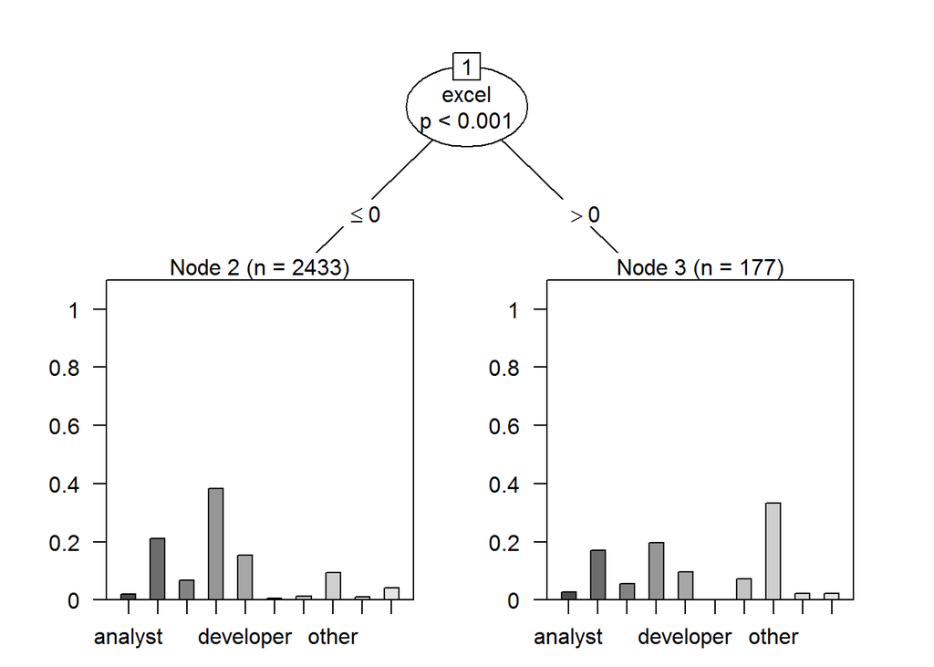

```r
#Create and plot ctree of dataframe - partial set - 1
skill_ctreeb <- ctree(role2 ~ excel, data=wide_5)
plot(skill_ctreeb)
```

```r
levels(wide_5$role2)
```

```
##  [1] "analyst"        "analytics"      "data-engr"      "data-scientist"
##  [5] "developer"      "engineer"       "manager"        "other"
##  [9] "scientist"      "statistician"
```

```r
# Predict by Random Forest Method
#names(wide_3)
#wide_2$role_desc

# Create a predictive model of the data - rf
rf <- randomForest(target2,data=wide_3,ntree=1000,proximity=TRUE)
#table(predict(rf),wide_2$role_desc)

names(wide_3)
```

```
##  [1] "role_desc"                 "bi"
##  [3] "nlp"                       "amazons3"
##  [5] "bigdata"                   "businessacumen"
##  [7] "businessintelligence"      "cassandra"
##  [9] "classification"            "clustering"
## [11] "communication"             "curious"
## [13] "d3"                        "d3.js"
## [15] "datamining"                "datavisualization"
## [17] "databaseadministration"    "dato"
## [19] "decisiontree"              "deeplearning"
## [21] "entrepreneur"              "entrepreneurial"
## [23] "excel"                     "flume"
## [25] "ggplot"                    "hadoop"
## [27] "hbase"                     "hive"
## [29] "intellectualcuriosity"     "java"
```

[output cut: 22 more lines]

```r
#str(wide_3)
#count(wide_3,2:67)

newdata <- data.frame(bi=0,
                      nlp = 0,
                      amazons3=0,
                      bigdata=1,
                      businessacumen=1,
                      businessintelligence = 0,
                      cassandra = 0,
                      classification = 1,
                      clustering =1,
                      communication=1,
                      curious=1,
                      d3=0,
                      d3.js=0,
                      datamining=1,
                      datavisualization=1,
                      databaseadministration=0,
                      dato=0,
                      decisiontree=1,
                      deeplearning=0,
                      entrepreneur=0,
                      entrepreneurial=0,
                      excel=1,
                      flume=0,
                      ggplot=1,
                      hadoop=1,
                      hbase=0,
                      hive=0,
                      intellectualcuriosity=1,
                      java=0,
                      knime=1,
                      machinelearning=1,
                      mahout=0,
                      mapreduce=0,
                      math=1,
                      matlab=0,
                      minitab=0,
                      mongodb=1,
                      naturallanguageprocessing=0,
                      neuralnetwork=0,
                      oozie=0,
                      optimization=1,
                      pandas=0,
                      pig=0,
                      predictiveanalytics=1,
                      predictivemodeling=1,
                      probability=1,
                      productdevelopment=0,
                      projectmanagement=0,
                      python=1,
                      r=1,
                      randomforest=1,
                      rapidminer=1,
                      regression=1,
                      rf=0,
                      rn=0,
                      ruby=0,
                      sas=0,
                      scala=1,
                      shark=0,
                      simulation=1,
                      softwareengineering=0,
                      spark=1,
                      spss=0,
                      sql=1,
                      stata=0,
                      statistics=1,
                      structured=0,
                      structureddata=0,
                      tableau=0,
                      textmining=0,
                      timeseries=0,
                      unstructureddata=1,
                      zookeeper=0
                      )

# Prediction - single test data - large data set
p <- predict(rf,newdata)
p
```

```
##              1
## data-scientist
## 188 Levels: advanced-analytics-data-scient ...
```

```r
#prediction: data-scientist

# Accuracy - single test data - large data set
mean(p == wide_3$role_desc)
```

```
## [1] 0.1544061
```

```r
#[1] 0.1544061

target2b <- role2 ~ .
rf2 <- randomForest(target2b,data=wide_5,ntree=1000,proximity=TRUE)

# Prediction - single test data - small data set
p2 <- predict(rf2,newdata)
p2
```

```
##              1
## data-scientist
## 10 Levels: analyst analytics data-engr data-scientist ... statistician
```

```r
#prediction: data-scientist

# Accuracy - single test data - small data set
mean(p2 == wide_5$role2)
```

```
## [1] 0.3701149
```

```r
#[1] 0.3701149

# Create a set of training and test data
train = sample(1:nrow(wide_5), 500)
wide_5_train <- wide_5[train,]
#str(wide_5_train)
levels(wide_5_train$role2)
```

```
##  [1] "analyst"        "analytics"      "data-engr"      "data-scientist"
##  [5] "developer"      "engineer"       "manager"        "other"
##  [9] "scientist"      "statistician"
```

```r
wide_5_test <- wide_5[-train,]

rf3 <- randomForest(target2b,data=wide_5_train,ntree=1000,proximity=TRUE)

# Prediction - single test data - training data set
p3 <- predict(rf3,newdata)
p3
```

```
##              1
## data-scientist
## 10 Levels: analyst analytics data-engr data-scientist ... statistician
```

```r
#prediction: data-scientist

# Accuracy - single test data - training model
mean(p3 == wide_5_train$role2)
```

```
## [1] 0.366
```

```r
#[1] 0.382

# Prediction - full test data - training data set
p4 <- predict(rf3,wide_5_test)
#p4

# Accuracy - full test data - training model
mean(p4 == wide_5_test$role2)
```

```
## [1] 0.3838863
```

```r
#[1] 0.3578199
```

##### Future work:

1). Continue to clean data set and test additional combinations of skills for improved insight and results (shape and refine). 2). Vigorously prune the data, and iterate, until best results are achieved.

### Team Conclusion:

*Extensive graphs* were provided to evaluate the data. Overall the top skills were communication, followed by Excel, JAVA, SQL, machine learning, and Python. For *data scientists*, Machine learning, Excel, Python, statistics, Hadoop, R, and communication were the top skills found. Job postings were analyzed for top cities (Seattle, Chicago, and Plano,Texas) and states (Washington, California, and Texas) offering data science jobs. There was an interactive graph to view the most popular data science skills by a user selected city using the R datatable function. Predictive analytics (ctree, predict, and random forest) were done to show what role a person is bested suited for based on his or her skills. Techniques were shown to *improve the accuracy* of the models.

The group learned to work together as a data science team, sharing technologies and techniques learned along the way, expanding skills in collaboration, planning, and delivering on time within a structure as directed by the project manager.